# Lecture #3: Working With R Studio

Nicholas J. Gotelli

January 24, 2017

### Window appearance

- sizing of window boundaries
- window screens

### Options to set

- `general` set default directory
- restore project and documents
- `code` do not insert matching parentheses and quotes
- default keybindings (not Vim or eMacs)
- `pane layout` - as set up
- `appearance` - choices for color, font, size

### File Names and Types

- `Plain Text` human-readable characters (none are unprinted)
  - not proprietary
  - readable by any computer system
  - readable wtih any `Plain Text Editor`
- `WYSIWYG` what you see is what you get
- `WYSIWYW` what you see is what you want
  - plain text codes to indicate formatting
  - no time lost using the mouse
  - separates writing from formatting, allowing you to concentrate on the former
- `Markdown` a language of simple plain text codes for rendering (= “knitting” a file into a different output format (`.html`,`.pdf`, and `.doc`)
- `.Rmd` is Rstudio’s special blend of Markdown (a text rendering language)
- `.md` is the more generic Markdown file type. In RStudio, the intermediate `.md` files are not (in the default state) preserved.

### Languages

- `LaTeX` Typesetting language invented in the 1970s by computer programmer Donald Knuth for proper rendering of text and equations. Hundreds of commands. Precise, but somewhat complicated to use.
- `Markdown` Greatly simplified version of LaTeX with a small number of commands to master. Easy to use, text looks great.
- `yaml`[^1]. Header material for `.Rmd` files that can be changed manually or by selecting options.
- `R` Computer language for manipulating numbers, text, graphics, statistics.

### Using R-markdown

- pull up cheatsheet
- new `.Rmd` file

### Basic text formatting

- headers
- text
- markup
  - italic
  - bold-face
  - subscript
  - superscript
  - strikethrough
  - quotations

### Spacing, manual breaks, lines

- line spacing effects
- two extra spaces at the end of a line for a manual break
- lists
  - indented
  - numbered

### Links

- links linking text
- footnotes[^2]
- images

  ```
  ![image link](website address)
  ```

### Tables

```
First Header  | Second Header
------------- | -------------
Content Cell  | Content Cell
Content Cell  | Content Cell
```

- also the `kable` package for later

  ```
  {r, echo=TRUE,results='asis'}
  library(knitr)
  kable(head(iris))
  ```

```r
library(knitr)
kable(head(iris))
```

| Sepal.Length | Sepal.Width | Petal.Length | Petal.Width | Species |
| --- | --- | --- | --- | --- |
| 5.1 | 3.5 | 1.4 | 0.2 | setosa |
| 4.9 | 3.0 | 1.4 | 0.2 | setosa |
| 4.7 | 3.2 | 1.3 | 0.2 | setosa |
| 4.6 | 3.1 | 1.5 | 0.2 | setosa |
| 5.0 | 3.6 | 1.4 | 0.2 | setosa |
| 5.4 | 3.9 | 1.7 | 0.4 | setosa |

### Fencing

- in line fencing `to shade`
- in line R code for calculations 6.1415927
- simple fencing to set off large chunks of plain text

### Equations

- in-line `$`
- centered `$$`
- basic math and text spacing handled by LateX

```
$$y = a + b$$
```

$$y = a + b$$

#### Subcripts

```
$$H_0 = Z_{a + b}$$
```

$$H_0 = Z_{a + b}$$

#### Superscripts

```
$$S = cA^z$$
```

$$S = cA^z$$

Contrast this with the construction of superscripts in Markdown

```
Markdown z^x^
```

z<sup>x</sup>

```
LaTeX: $z^x$
```

$z^x$

```
Markdown: z^x + 1^
```

z^x + 1^

```
LaTeX: $z^{x + 1}$
```

$z^{x + 1}$

```
Markdown: z^x+1^
```

z<sup>x+1</sup>

```
LaTeX: $z^{x+1}$
```

$z^{x+1}$

- elements can be coupled and nested

$$S=cA^z_1 + z_{2 + x}$$

```
$$S=cA^z_1 + z_{2 + x}$$
```

#### Fractions and Greek Symbols

$$\alpha = \frac{\beta}{\delta + \gamma_x}$$

```
$$\alpha = \frac{\beta}{\delta + \gamma_x}$$
```

#### Summation signs

$$z = \sum_{i=1}^X{K}$$

```
$$z = \sum_{i=1}^X{K}$$
```

#### “Escaping” the special character in LaTeX

Use `\backslash`

```
$$\backslash \alpha \le b \backslash$$
```

$$\backslash \alpha \le b \backslash$$

#### Rendering plain text in a LaTex Equation

$$P(Occurrence Of Species A) = Z$$

```
$$P(Occurrence Of Species A) = Z$$
```

$$P(\mbox{Occurrence Of Species A}) = Z$$

```
$$P(\mbox{Occurrence Of Species A}) = Z$$
```

### R Code in Chunks

- `CTRL-ALT-I` inserts a new “chunk” of R code

```r
# Use comments extensively in ALL of your coding!
Pred <- seq(1,10)     # make a vector of integers from 1 to 10
Res <- runif(10)      # generate 10 draws from a random uniform (0,1) distribution

# print the random numbers
print(Res)
```

```
##  [1] 0.47074624 0.27245182 0.59638345 0.15555957 0.83231461 0.73757666
##  [7] 0.28756084 0.06925926 0.64023222 0.73860095
```

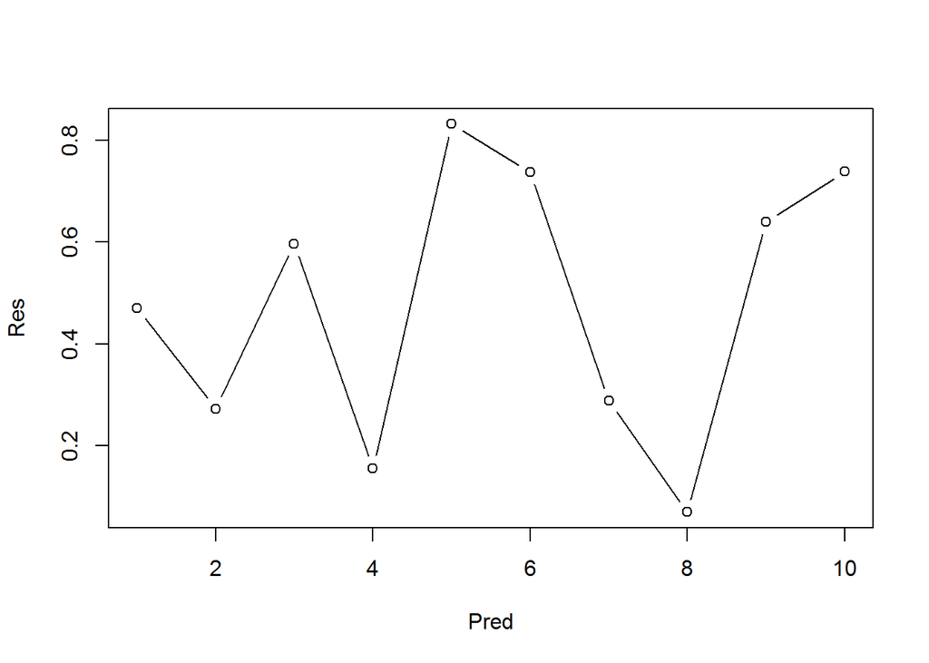

```r
# plot the graph
plot(x=Pred,y=Res,type="b")
```

### Using chunk options to control printing of code and output

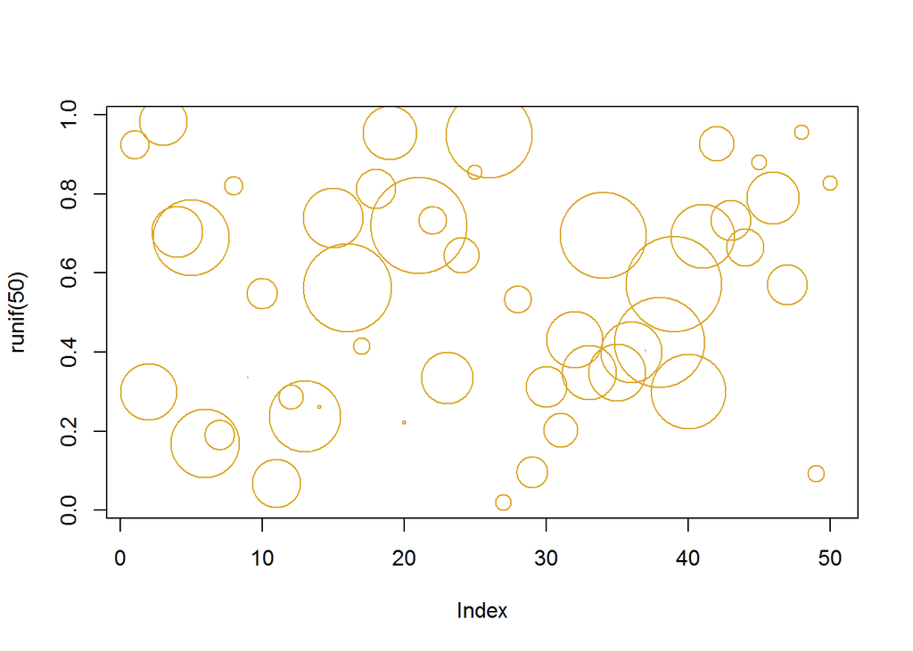

```r
plot(runif(50),cex=10*runif(50),col="goldenrod")
```

```r
print(rnorm(n=10, mean=10, sd=2))
```

```
##  [1] 10.145111 11.797989  7.553975 12.554239 11.842764 10.432404  7.927422
##  [8] 10.699411  9.794006 11.193659
```

### Writing R scripts

- new script
- code executes and prints in console
- graphs in output window
- `CTRL - ENTER` to run a single line of code
- `CTRL - SHIFT - ENTER` to source the entire script
- code to illustrate:

  ```
  # Use comments extensively throughout your code
  Time <- seq(1,10) # Create a vector of integers, 1 to 10
  Resp <- runif(10) # Create 10 random uniform (0,1) variates
  #
  print(Time)
  print(Resp)
  #
  # Plot the data
  plot(x=Time,y=Resp,type="b")
  ```

### Converting `.R` files to `.html` (creating an R notebook)

- use notebook script
- roxygen comments ``#`

### `Purling` to strip and consolidate R chunks from a Markdown file

- commands executed from console

```
library(knitr)
purl("FileName.Rmd")
```

These commands will create a file `FileName.R` that has all of the R code and none of the markdown text. R comments are still retained.

### Bonus: A Cool New Markdown Editor!

- Demo of `Typora` a WYSIWYG text editor at https://typora.io/
[^1]: Originally “Yet Another Markdown Language”, but more recently “YAML Ain’t no Markdown Language”, which is a self-referencing acronym
[^2]: Footnoted text, consecutively at bottom of page